# Collaborative filtering recommender (CFR) System

Chirag Vithalani

May 9, 2017

## Collaborative Filtering

### Definition

Collaborative filtering is a method of making automatic predictions (filtering) about the interests of a user by collecting preferences or taste information from many users.

[figure not shown]

### Data Input

MovieLens Latest Datasets is available at https://grouplens.org/datasets/movielens/latest/

File Name : ml-latest-small.zip File Direct download URL : http://files.grouplens.org/datasets/movielens/ml-latest-small.zip

Download above zip file,unzip and read movies.csv and ratings.csv files

```r
#reading files
movies <- read.csv("movies.csv",stringsAsFactors=FALSE)

ratings <- read.csv("ratings.csv")
```

Printing first three rows of movies object

```r
head(movies,3)
```

```
##   movieId                   title
## 1       1        Toy Story (1995)
## 2       2          Jumanji (1995)
## 3       3 Grumpier Old Men (1995)
##                                        genres
## 1 Adventure|Animation|Children|Comedy|Fantasy
## 2                  Adventure|Children|Fantasy
## 3                              Comedy|Romance
```

Printing first three rows ratings object

```r
head(ratings,3)
```

```
##   userId movieId rating  timestamp
## 1      1      16    4.0 1217897793
## 2      1      24    1.5 1217895807
## 3      1      32    4.0 1217896246
```

## Data Processing

Re-organize the information of movie categories so that it is easy to organize it.

### Extract a list of categories

```r
genres <- as.data.frame(movies$genres, stringsAsFactors=FALSE)
#strsplit and transpose the resulting list efficiently
categoryDF <- as.data.frame(tstrsplit(genres[,1], '[|]', type.convert=TRUE),stringsAsFactors=FALSE)

colnames(categoryDF) <- c(1:10)
#  19 different categories in total
category_list <- c("Action", "Adventure", "Animation", "Children","Comedy", "Crime","Documentary", "Drama", "Fantasy","Film-Noir", "Horror", "Musical", "Mystery","Romance","Sci-Fi", "Thriller", "War", "Western","IMAX")

category_matrix <- matrix(0,10330,19)
category_matrix[1,] <- category_list
colnames(category_matrix) <- category_list

#Loop through all elements
for (i in 1:nrow(categoryDF))
{
  for (c in 1:ncol(categoryDF))
  {
    which_col = which(category_matrix[1,] == categoryDF[i,c])
    category_matrix[i+1,which_col] <- 1
  }
}

#convert into dataframe

#remove category which is first row
category_matrix2 <- as.data.frame(category_matrix[-1,], stringsAsFactors=FALSE)

for (c in 1:ncol(category_matrix2))
{
  category_matrix2[,c] <- as.integer(category_matrix2[,c])  #convert from characters to integers
}

#head(category_matrix2)

search_matrix <- cbind(movies[,1:2], category_matrix2)
head(search_matrix,1)
```

```
##   movieId            title Action Adventure Animation Children Comedy
## 1       1 Toy Story (1995)      0         1         1        1      1
##   Crime Documentary Drama Fantasy Film-Noir Horror Musical Mystery Romance
## 1     0           0     0       1         0      0       0       0       0
##   Sci-Fi Thriller War Western IMAX
## 1      0        0   0       0    0
```

### Coerce into a realRatingMAtrix

Using realRatingMatrix

```r
#Create ratings matrix. Rows = userId, Columns = movieId
ratingmat <- dcast(ratings, userId~movieId, value.var = "rating", na.rm=FALSE)
ratingmat <- as.matrix(ratingmat[,-1])

## coerce into a realRatingMAtrix
ratingmat <- as(ratingmat, "realRatingMatrix")
```

## Rating distribution

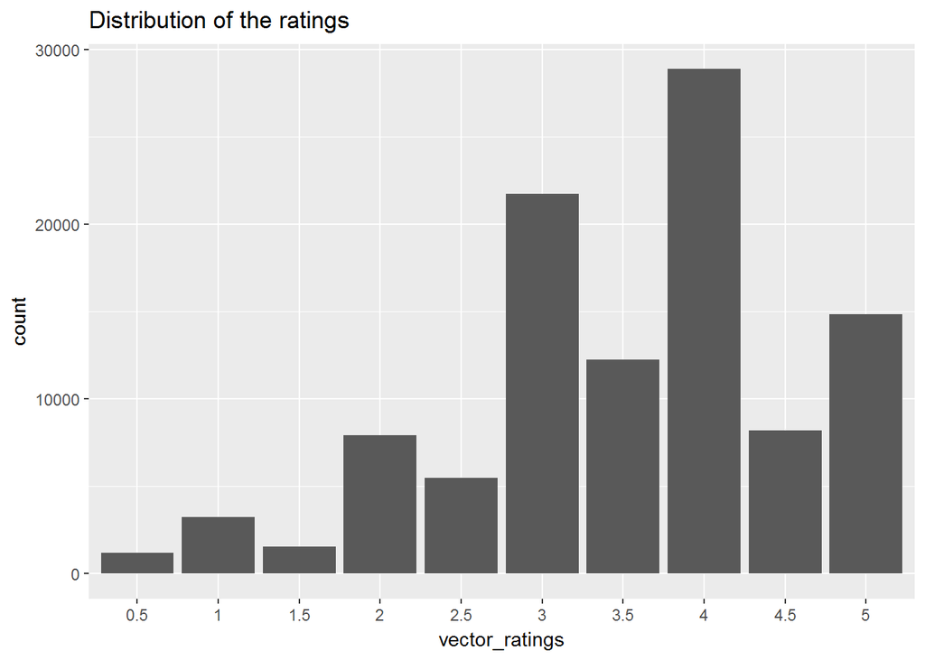

```r
vector_ratings <- as.vector(ratingmat@data)
vector_ratings <- vector_ratings[vector_ratings != 0] # rating == 0 are NA values
vector_ratings <- factor(vector_ratings)

qplot(vector_ratings) + ggtitle("Distribution of the ratings")
```

Looks like most people are giving higher rating.

## Trimming to meaningful data

In order to select the most relevant data, I define the minimum number of users per rated movie as 50 and the minimum views number per movie as 50:

```r
trimmed_movies <- ratingmat[rowCounts(ratingmat) > 50,colCounts(ratingmat) > 50]
trimmed_movies
```

```
## 420 x 447 rating matrix of class 'realRatingMatrix' with 38341 ratings.
```

Such a selection of the most relevant data contains 420 users and 447 movies, compared to previous 668 users and 10325 movies in the total dataset.

## ITEM-based Collaborative Filtering Model

Item-item collaborative filtering is a form of collaborative filtering for recommender systems based on the similarity between items calculated using people’s ratings of those items.

## Defining training/test sets

I build the model using 80% of the whole dataset as a training set, and 20% - as a test set.

```r
# Random Samples and Permutations
sample <- sample(x = c(TRUE, FALSE), size = nrow(trimmed_movies),replace = TRUE, prob = c(0.8, 0.2))

head(sample)
```

```
## [1] FALSE  TRUE  TRUE  TRUE  TRUE  TRUE
```

```r
train_data <- trimmed_movies[sample, ]
test_data <- trimmed_movies[!sample, ]

head(test_data)
```

```
## 1 x 447 rating matrix of class 'realRatingMatrix' with 88 ratings.
```

## Building the recommendation model

```r
#Recommender uses the registry mechanism from package registry to manage methods. This let's the user easily specify and add new methods. The registry is called recommenderRegistry.
recommender_models <- recommenderRegistry$get_entries(dataType ="realRatingMatrix")

recommender_models$IBCF_realRatingMatrix$parameters
```

```
## $k
## [1] 30
##
## $method
## [1] "Cosine"
##
## $normalize
## [1] "center"
##
## $normalize_sim_matrix
## [1] FALSE
##
## $alpha
## [1] 0.5
##
## $na_as_zero
## [1] FALSE
```

```r
#Create a Recommender Model
IBCF_recommender_model <- Recommender(data = train_data,method = "IBCF",parameter = list(k = 30))
```

## Doing recommendation on actual data

### Do the prediction

```r
recc_predicted <- predict(object = IBCF_recommender_model,newdata = test_data, n = 10)
recc_predicted
```

```
## Recommendations as 'topNList' with n = 10 for 69 users.
```

### Printing recommendation

```r
first_user_recommendation <- recc_predicted@items[[1]]
first_user_recommendation
```

```
##  [1] 177 146  62 126 344   6 139 318 237 140
```

```r
movies_IDs <- recc_predicted@itemLabels[first_user_recommendation]
movies_IDs
```

```
##  [1] "1207" "923"  "329"  "750"  "3081" "7"    "903"  "2699" "1527" "904"
```

```r
movie_names <- movies_IDs

for (i in 1:10)
{
  movie_names[i] <- as.character(subset(movies,movies$movieId == movies_IDs[i])$title)
}
movie_names
```

```
##  [1] "To Kill a Mockingbird (1962)"
##  [2] "Citizen Kane (1941)"
##  [3] "Star Trek: Generations (1994)"
##  [4] "Dr. Strangelove or: How I Learned to Stop Worrying and Love the Bomb (1964)"
##  [5] "Sleepy Hollow (1999)"
##  [6] "Sabrina (1995)"
##  [7] "Vertigo (1958)"
##  [8] "Arachnophobia (1990)"
##  [9] "Fifth Element, The (1997)"
## [10] "Rear Window (1954)"
```

IBCF recommends items on the basis of the similarity matrix. It’s an eager-learning model, that is, once it’s built, it doesn’t need to access the initial data. For each item, the model stores the k-most similar, so the amount of information is small once the model is built. This is an advantage in the presence of lots of data.

In addition, this algorithm is efficient and scalable, so it works well with big rating matrices.